# Estatística no R

Maurício Bueno

2022-11-29

Esta disciplina tem o objetivo de instrumentalizar o aluno para a realização das análises estatísticas mais empregadas em pesquisas em psicologia, no ambiente de programação R. Inicialmente, vamos carregar e ativar os pacotes que iremos utilizar na disciplina.

# Carregamento dos pacotes

```r
# if(!require(tidyverse)) install.packages("tidyverse")
# if(!require(psych)) install.packages("psych")
# if(!require(knitr)) install.packages("knitr")
# if(!require(kableExtra)) install.packages("kableExtra")
# if(!require(expss)) install.packages("expss")
# if(!require(janitor)) install.packages("janitor")
# if(!require(pander)) install.packages('pander')
# if(!require(arsenal)) install.packages('arsenal')
# if(!require(moments)) install.packages('moments')
# if(!require(readr)) install.packages('moments')
# if(!require(readxl)) install.packages('readxl')
# if(!require(descr)) install.packages("descr")
# if(!require(rcompanion)) install.packages("rcompanion")
# if(!require(rstatix)) install.packages("rstatix")

# install.packages("Rcpp")
# Ativação dos pacotes ====

library(tidyverse)
library(psych)
library(arsenal)
# library(rstatix)
# library(GPArotation)
library(corrplot)
library(janitor)
library(pander)
library(knitr)
# library(kableExtra)
# library(expss)
# library(readxl)
# library(readr)
```

# Importar banco de dados

Inicialmente vamos trabalhar com o banco de dados `dataset_mapfre.csv`, clique [aqui](https://docs.google.com/spreadsheets/d/1G0lQKeU0atMk3Q4wO5zz4HdvReRxKS68vx_Q0WbB37A/edit?usp=sharing) para baixá-lo. Salve-o como um dataframe chamado `dataset`.

Dica: Utilize a função `read.csv`, cujo argumento `stringsAsFactors=TRUE` já salva as variáveis categóricas como fator.

Esse banco de dados se refere ao artigo “[Sintomas de depressão e ansiedade em uma amostra representativa de universitários espanhóis, portugueses e brasileiros](https://drive.google.com/file/d/1qa0iCDm2DRvh3M6a2k7ENGahceDAlPIg/view?usp=sharing)”. Sugere-se a leitura desse artigo para a compreensão dos dados.

```r
dataset <- read.csv("dataset_mapfre.csv",encoding="UTF-8",stringsAsFactors=TRUE)

# OBS: Para que este comando funcione, é necessário que o arquivo csv esteja no diretório de trabalho do R.

# Observar o banco de dados
glimpse(dataset)
```

```
## Rows: 1,957
## Columns: 94
## $ country       <fct> SPAIN, SPAIN, SPAIN, SPAIN, SPAIN, SPAIN, SPAIN, SPAIN, …
## $ sex           <fct> NA, NA, NA, NA, NA, NA, NA, M, M, M, M, M, M, M, M, M, M…
## $ age           <int> 18, NA, 26, NA, 20, NA, NA, 19, 21, 21, 23, 21, 22, 20, …
## $ grado         <fct> "Educ.Infantil                                          …
## $ curso_ou_ano  <int> 1, 2, 4, 3, 1, NA, 3, 1, 3, 3, 4, 4, 4, 2, 4, 3, 3, 1, 1…
## $ ceri_1        <int> 1, 1, 1, 2, 1, 2, 1, 1, 1, 2, 3, 2, 1, 1, 2, 1, 2, 2, 1,…
## $ ceri_2        <int> 1, 2, 1, 2, 3, 2, 3, 1, 1, 3, 2, 3, 2, 2, 2, 1, 3, 3, 3,…
## $ ceri_3        <int> 2, 2, 2, 1, 2, 2, 3, 2, 1, 2, 1, 3, 2, 3, 2, 1, 3, 1, 2,…
## $ ceri_4        <int> 1, 1, 1, 2, 1, 1, 2, 1, 1, 3, 3, 3, 1, 2, 3, 1, 2, 1, 2,…
## $ ceri_5        <int> NA, 1, 2, 1, NA, 2, 2, 1, 1, 3, 1, 2, 2, 1, 2, 1, 2, 1, …
## $ ceri_6        <int> 2, 2, 1, 2, 1, 1, 2, 1, 2, 1, 4, 3, 3, 2, 3, 2, 2, 2, 1,…
## $ ceri_7        <int> 1, 1, 1, 1, 1, 2, 2, 1, 1, 2, 2, 1, 1, 2, 1, 1, 2, 1, 1,…
## $ ceri_8        <int> 1, 1, 1, 1, 2, 1, 2, 1, 1, 1, 1, 1, 1, 2, 2, 1, 2, 1, 1,…
```

[output cut: 81 more lines]

# Estatísticas

Este curso está didaticamente dividido em três tipos de análises estatísticas:

1. Estatísticas descritivas, que incluem as medidas de frequência, de tendência central e de dispersão.
2. Estatísticas que ajudam a compreender associação entre variáveis: qui-quadrado, correlação, regressão e análise fatorial.
3. Efeitos de grupo em outras variáveis: t-teste e análises de variância.

As próximas seções apresentam recursos para a realização dessas análises.

# Estatísticas descritivas de frequência

A forma mais simples de descrever algo quantitativamente é contando o número de ocorrências. Por exemplo, podemos descrever uma amostra quanto à escolaridade, contando as ocorrências de ensino fundamental, ensino médio e ensino superior. As formas mais comuns para sumariar esses dados de forma mais amigável para o leitor é através de **tabelas** e **gráficos**. Vamos ver essas formas a seguir.

## Tabelas de frequência com a função `table()`

```r
# Tabulando dados

table(dataset$country)
```

```
##
##   BRAZIL PORTUGAL    SPAIN
##      315      426     1216
```

```r
table1 <- table(dataset$country, dataset$sex)
table1 %>% pander()
```

|  | F | M |
| --- | --- | --- |
| **BRAZIL** | 166 | 149 |
| **PORTUGAL** | 223 | 203 |
| **SPAIN** | 825 | 384 |

```r
table1 %>% kable()
```

|  | F | M |
| --- | --- | --- |
| BRAZIL | 166 | 149 |
| PORTUGAL | 223 | 203 |
| SPAIN | 825 | 384 |

```r
# Tabulação em dataframe com porcentagens
table(dataset$country) %>%
  as.data.frame() %>%
  mutate("%" = Freq*100/sum(Freq)) %>%
  pander()
```

| Var1 | Freq | % |
| --- | --- | --- |
| BRAZIL | 315 | 16.1 |
| PORTUGAL | 426 | 21.77 |
| SPAIN | 1216 | 62.14 |

```r
table(dataset$country, dataset$sex) %>%
  as.data.frame() %>%
  mutate("%" = Freq*100/sum(Freq)) %>%
  pander()
```

| Var1 | Var2 | Freq | % |
| --- | --- | --- | --- |
| BRAZIL | F | 166 | 8.513 |
| PORTUGAL | F | 223 | 11.44 |
| SPAIN | F | 825 | 42.31 |
| BRAZIL | M | 149 | 7.641 |
| PORTUGAL | M | 203 | 10.41 |
| SPAIN | M | 384 | 19.69 |

```r
table(dataset$country, dataset$sex, dataset$bai_class) %>%
  as.data.frame() %>%
  mutate("%" = Freq*100/sum(Freq)) %>%
  pander()
```

| Var1 | Var2 | Var3 | Freq | % |
| --- | --- | --- | --- | --- |
| BRAZIL | F | grave | 5 | 0.2571 |
| PORTUGAL | F | grave | 8 | 0.4113 |
| SPAIN | F | grave | 25 | 1.285 |
| BRAZIL | M | grave | 4 | 0.2057 |
| PORTUGAL | M | grave | 5 | 0.2571 |
| SPAIN | M | grave | 6 | 0.3085 |
| BRAZIL | F | leve | 40 | 2.057 |
| PORTUGAL | F | leve | 55 | 2.828 |
| SPAIN | F | leve | 178 | 9.152 |
| BRAZIL | M | leve | 28 | 1.44 |
| PORTUGAL | M | leve | 23 | 1.183 |
| SPAIN | M | leve | 50 | 2.571 |
| BRAZIL | F | minima | 105 | 5.398 |
| PORTUGAL | F | minima | 141 | 7.249 |
| SPAIN | F | minima | 551 | 28.33 |
| BRAZIL | M | minima | 107 | 5.501 |
| PORTUGAL | M | minima | 167 | 8.586 |
| SPAIN | M | minima | 309 | 15.89 |
| BRAZIL | F | moderada | 16 | 0.8226 |
| PORTUGAL | F | moderada | 19 | 0.9769 |
| SPAIN | F | moderada | 71 | 3.65 |
| BRAZIL | M | moderada | 10 | 0.5141 |
| PORTUGAL | M | moderada | 6 | 0.3085 |
| SPAIN | M | moderada | 16 | 0.8226 |

## Tabelas de frequência com a função `count()`

```r
# Contar uma variável
dataset %>%
  count(sex) %>%
  mutate("%" = n*100/sum(n)) %>%
  pander()
```

| sex | n | % |
| --- | --- | --- |
| F | 1214 | 62.03 |
| M | 736 | 37.61 |
| NA | 7 | 0.3577 |

```r
# Contar uma variável x em função de uma y, com totalização integral.

dataset %>%
  count(sex,country) %>%
  mutate("%" = n*100/sum(n)) %>%
  pander()
```

| sex | country | n | % |
| --- | --- | --- | --- |
| F | BRAZIL | 166 | 8.482 |
| F | PORTUGAL | 223 | 11.39 |
| F | SPAIN | 825 | 42.16 |
| M | BRAZIL | 149 | 7.614 |
| M | PORTUGAL | 203 | 10.37 |
| M | SPAIN | 384 | 19.62 |
| NA | SPAIN | 7 | 0.3577 |

```r
# Contar uma variável x em função de outra y, com totalização pelas categorias de x.

dataset %>%
  filter(!is.na(sex)) %>%
  group_by(sex) %>%
  count(country) %>%
  mutate(porc = n/sum(n)*100) %>%
  pander()
```

| sex | country | n | porc |
| --- | --- | --- | --- |
| F | BRAZIL | 166 | 13.67 |
| F | PORTUGAL | 223 | 18.37 |
| F | SPAIN | 825 | 67.96 |
| M | BRAZIL | 149 | 20.24 |
| M | PORTUGAL | 203 | 27.58 |
| M | SPAIN | 384 | 52.17 |

## Tabelas de frequência com o pacote `janitor`

```r
# install.packages("janitor")
# library(janitor)

# usando a função tabyl() do pacote janitor
# contar quantas pessoas de cada país.

dataset %>%             # pegar o dataframe dataset
  tabyl(country) %>%    # use a função tabyl para tabular as categorias de país
  pander()              # utilize o pander para fazer a tabela
```

| country | n | percent |
| --- | --- | --- |
| BRAZIL | 315 | 0.161 |
| PORTUGAL | 426 | 0.2177 |
| SPAIN | 1216 | 0.6214 |

```r
dataset %>%             # pegar o dataframe dataset
  tabyl(country) %>%    # use a função tabyl para tabular as categorias de país
  adorn_totals() %>%    # acrescente uma linha com os totais
  pander()              # utilize o pander para fazer a tabela
```

| country | n | percent |
| --- | --- | --- |
| BRAZIL | 315 | 0.161 |
| PORTUGAL | 426 | 0.2177 |
| SPAIN | 1216 | 0.6214 |
| Total | 1957 | 1 |

```r
dataset %>%             # pegar o dataframe dataset
  tabyl(country) %>%    # use a função tabyl para tabular as categorias de país
  adorn_totals() %>%    # acrescente uma linha com os totais
  adorn_pct_formatting(digits = 1) %>%
  pander()              # utilize o pander para fazer a tabela
```

| country | n | percent |
| --- | --- | --- |
| BRAZIL | 315 | 16.1% |
| PORTUGAL | 426 | 21.8% |
| SPAIN | 1216 | 62.1% |
| Total | 1957 | 100.0% |

```r
# contar por gênero e país (retirando NAs)
dataset %>%
  filter(!is.na(sex)) %>%
  tabyl(sex,country) %>%
  adorn_totals() %>%
  pander()
```

| sex | BRAZIL | PORTUGAL | SPAIN |
| --- | --- | --- | --- |
| F | 166 | 223 | 825 |
| M | 149 | 203 | 384 |
| Total | 315 | 426 | 1209 |

```r
dataset %>%
  filter(!is.na(sex)) %>%
  tabyl(sex,country) %>%
  adorn_totals(c("row","col")) %>%
  pander()
```

| sex | BRAZIL | PORTUGAL | SPAIN | Total |
| --- | --- | --- | --- | --- |
| F | 166 | 223 | 825 | 1214 |
| M | 149 | 203 | 384 | 736 |
| Total | 315 | 426 | 1209 | 1950 |

```r
dataset %>%
  drop_na(sex) %>%        # outra forma de eliminar os NAs
  tabyl(sex,country) %>%
  adorn_totals(c("row","col")) %>%
  pander()
```

| sex | BRAZIL | PORTUGAL | SPAIN | Total |
| --- | --- | --- | --- | --- |
| F | 166 | 223 | 825 | 1214 |
| M | 149 | 203 | 384 | 736 |
| Total | 315 | 426 | 1209 | 1950 |

```r
dataset %>%
  tabyl(sex,country,show_na = FALSE) %>% # eliminar NAs com argumento do próprio janitor
  adorn_totals(c("row","col")) %>%
  pander()
```

| sex | BRAZIL | PORTUGAL | SPAIN | Total |
| --- | --- | --- | --- | --- |
| F | 166 | 223 | 825 | 1214 |
| M | 149 | 203 | 384 | 736 |
| Total | 315 | 426 | 1209 | 1950 |

```r
# contar por gênero e país, acrescentando funções
dataset %>%
  tabyl(country,sex, show_na = FALSE) %>%           # função de tabulação do janitor
  adorn_totals(c("row","col")) %>% # adiciona o N
  adorn_percentages("all") %>%     # adiciona porcentagens (One of "row", "col", or "all".)
  adorn_pct_formatting(
    rounding = "half up",          # arredondar do cinco pra cima
    digits = 0) %>%                # número de casas decimais
  adorn_ns() %>%                   # mostra N e % juntas
  pander()                         # melhora a visualização dos dados.
```

| country | F | M | Total |
| --- | --- | --- | --- |
| BRAZIL | 9% (166) | 8% (149) | 16% (315) |
| PORTUGAL | 11% (223) | 10% (203) | 22% (426) |
| SPAIN | 42% (825) | 20% (384) | 62% (1209) |
| Total | 62% (1214) | 38% (736) | 100% (1950) |

```r
# adição de um qui-quadrado para a distribuição
# para rodar essa análise tem que tirar os totais.

dataset %>%
  filter(!is.na(sex)) %>%
  tabyl(country,sex) %>%           # função de tabulação do janitor
  adorn_totals(c("row","col")) %>% # adiciona o N
  chisq.test()
```

```
##
##  Pearson's Chi-squared test
##
## data:  .
## X-squared = 48.458, df = 2, p-value = 3.003e-11
```

```r
  # pander()                         # melhora a visualização dos dados.
```

## Gráficos de frequência com o pacote `ggplot2`

### Gráficos de barras

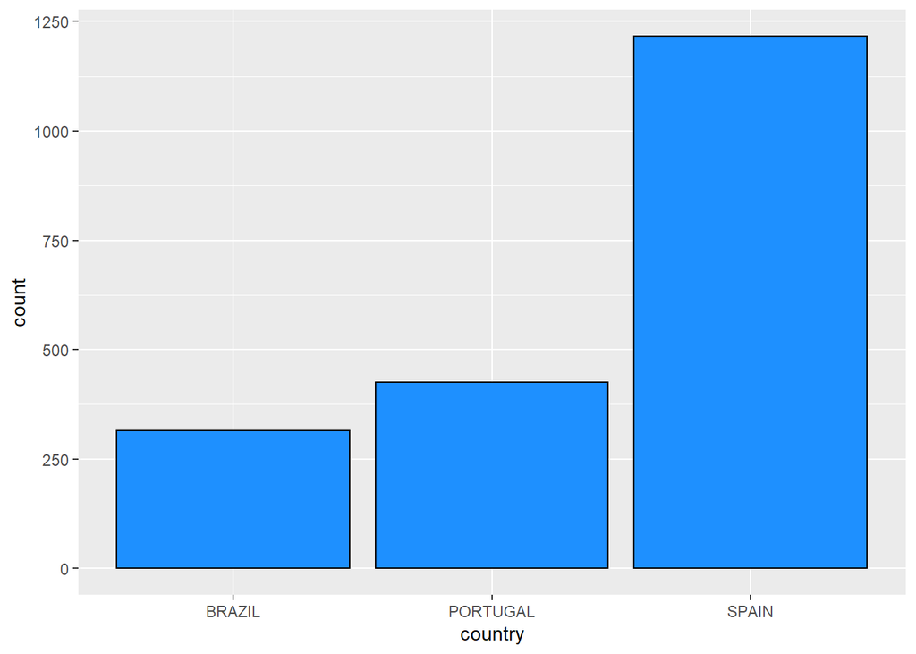

```r
# Gráfico mais simples possível (contagem simples)
ggplot(dataset, aes(x = country)) +
  geom_bar(color = "black", fill = "dodgerblue")
```

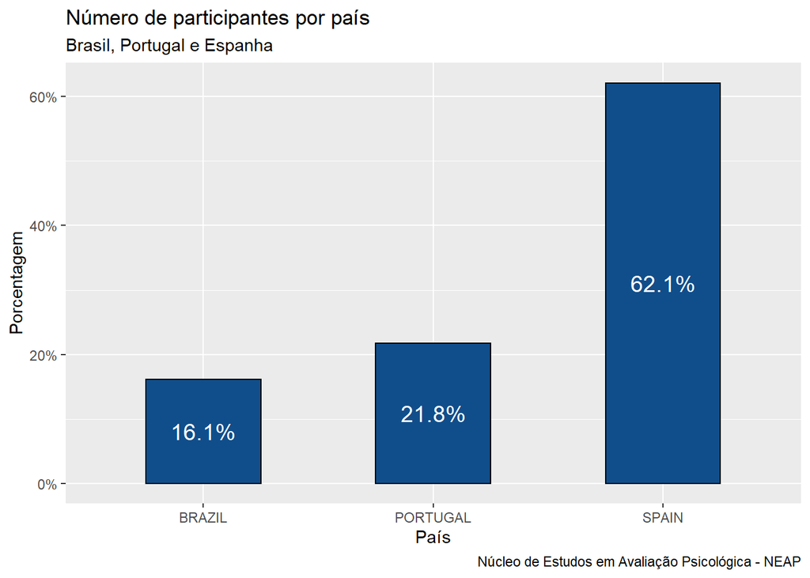

```r
# Gráfico de barras mais complexo (4)

## Camada 1 - gráfico de barras com algumas melhorias visuais

ggplot(data = dataset,             # base de dados
       mapping = aes(x = country,  # informação que vai no eixo x
                     y = ..prop.., # informação que vai no eixo y: forma de indicar que é a proporção
                     group = 1)) +
  geom_bar(stat = "count",         # definir que a estatística parte da contagem
           fill = "dodgerblue4",   # cor das barras
           width = .5,             # espessura das barras
           color = "black") +      # cor da borda das barras

## Camada 2 - colocar eixo y em porcentagem
    scale_y_continuous(labels = scales::percent_format()) +

## Camada 3 - colocar o valor das porcentagens nas barras
  geom_text(aes(label = scales::percent(..prop..),
                y = ..prop..),
            stat = "count",
            color = "white",
            size = 5,
            position = position_stack(vjust = 0.5)) +

## Camada 4 - Titulos, labels
    labs(x = "País",
       y = "Porcentagem",
       title = "Número de participantes por país",
       subtitle = "Brasil, Portugal e Espanha",
       caption = "Núcleo de Estudos em Avaliação Psicológica - NEAP")
```

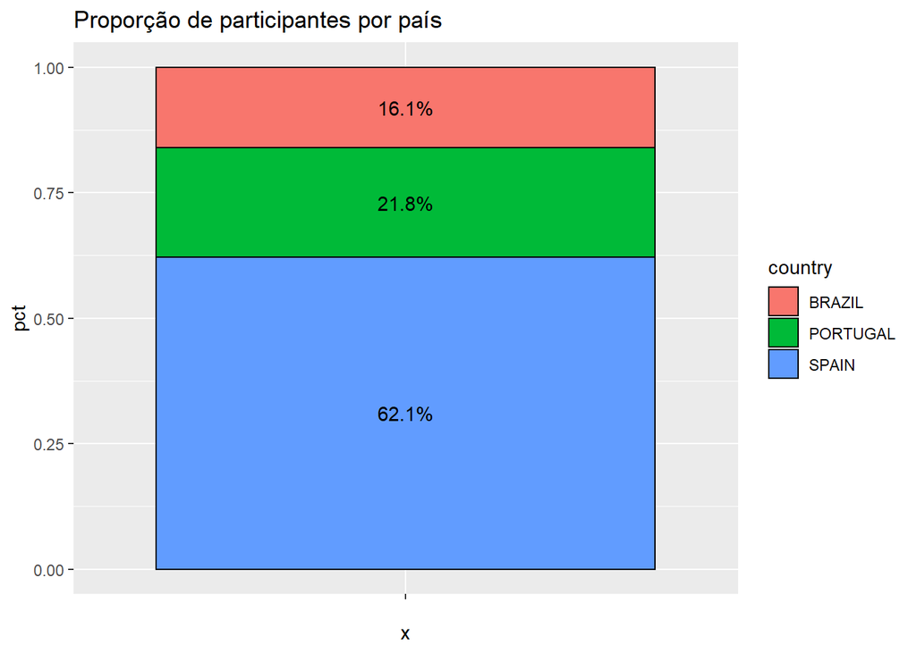

```r
# Gráfico de barras empilhadas (utilizando o geom_col)
# OBS.: O geom_col é parecido com o geom_bar, mas o primeiro só aceita dados diretos.
# Por isso, nesse caso, é preciso preparar o dataframe antes.

## Preparação do data frame
dataset %>%
  count(country) %>%
  mutate(pct = n/sum(n)) %>%
## Camada 1
  ggplot(.,aes(x = "",
               y = pct,
               fill = country)) + # se o argumento fill for colocado dentro de aes, sai uma cor por barra
  geom_col(color = "black") +
## Camada 2
  geom_text(aes(label = scales::percent(round(pct,3))),
            position = position_stack(vjust = 0.5)) +
## Camada 3
  labs(title = "Proporção de participantes por país")
```

### Gráficos de pizza

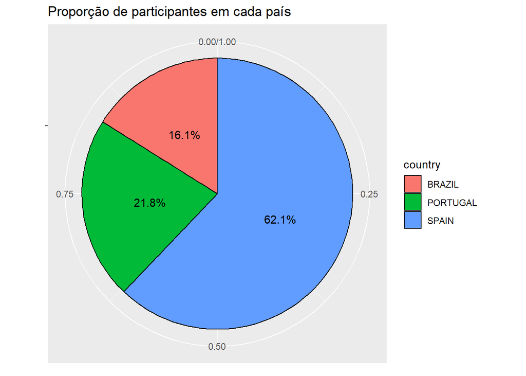

```r
# é um gráfico de barras empilhadas transformado em polar

## preparação dos dados
dataset %>%
  count(country) %>%
  mutate(pct = n/sum(n)) %>%
# Camada 1
  ggplot(.,aes(x = "", y = pct, fill = country)) +
  geom_col(color = "black") +
# Camada 2
  geom_text(aes(label = scales::percent(round(pct,3))),
            position = position_stack(vjust = 0.5)) +
# Camada 3
  coord_polar(theta = "y") +
# Camada 4
  labs(title = "Proporção de participantes em cada país") +
   xlab(NULL) +
   ylab(NULL)
```

### Gráficos de linhas

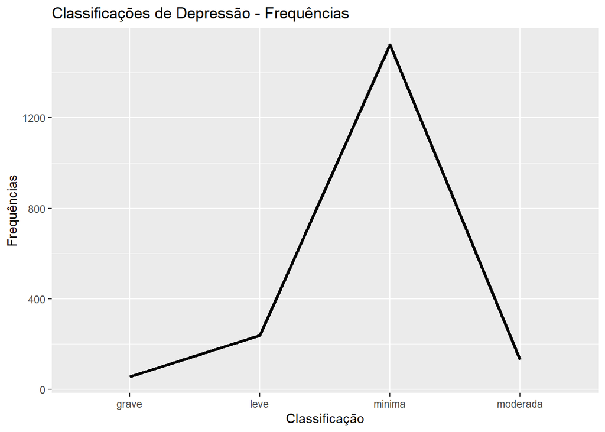

```r
# Contar categorias dentro de uma variável (nível de depressão)

dataset %>%
  drop_na(bdi_class) %>%
  ggplot() +
  geom_line(aes(x = bdi_class, group = 1), stat = "count", size = 1.2) +
  labs(title = "Classificações de Depressão - Frequências",
       x = "Classificação",
       y = "Frequências")
```

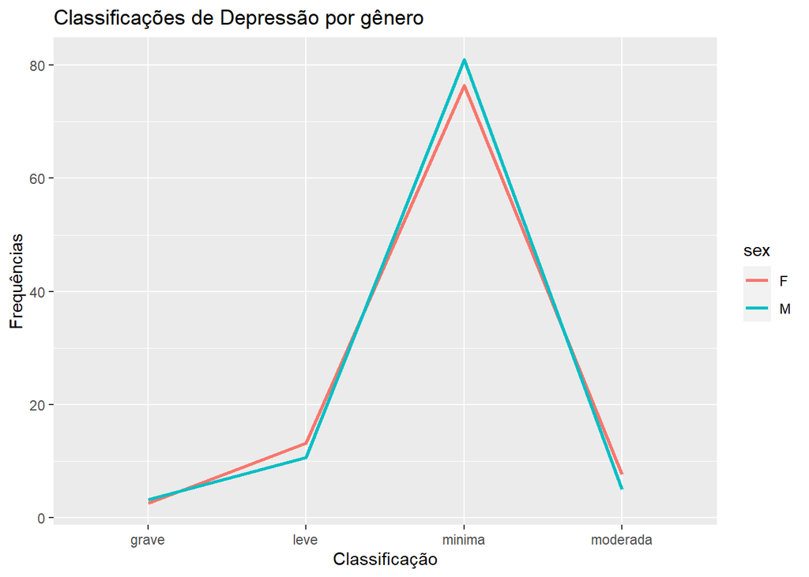

```r
# Misturando variáveis (frequência de classificações por gênero)

## preparação dos dados
dataset %>%
  drop_na(bdi_class,sex) %>%
  group_by(sex) %>%
  count(bdi_class,sex) %>%
  mutate(porc = n*100/(sum(n))) %>%
## camada 1
  ggplot() +
  geom_line(aes(x = bdi_class,
                y = porc,
                group = sex,
                color = sex),
            size = 1.0) +
## camada 2
  labs(title = "Classificações de Depressão por gênero",
       x = "Classificação",
       y = "Frequências")
```

# Estatísticas descritivas de tendência central e de dispersão

A descrição dos dados geralmente é realizada pelas seguintes estatísticas: Média, desvio padrão, mediana, amplitude, mínimo, máximo, assimetria e curtose. Algumas dessas análises (média, desvio padrão e mediana) informam sobre o ponto central da distribuição das medidas. Outras, como o desvio padrão, a amplitude, a assimetria e a curtose informam sobre a forma como os valores se afastam do ponto central.

Aqui, é importante atentar para a **distribuição normal**, cujas características são apresentadas na Figura abaixo.

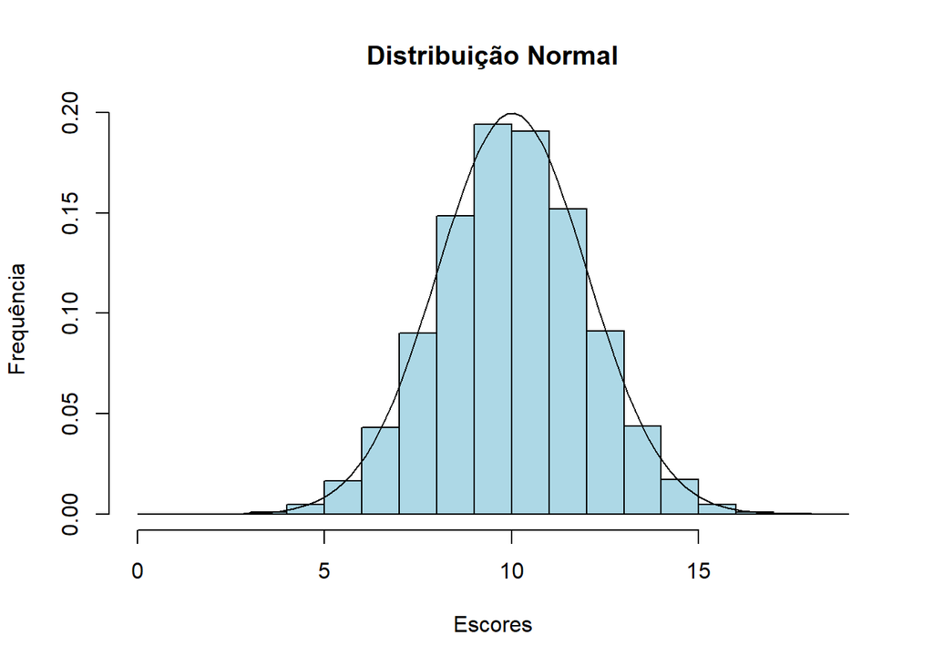

### Medidas de tendência central

```r
## mean()
mean(dataset$age, na.rm = TRUE)
```

```
## [1] 21.46034
```

```r
## sd()
sd(dataset$age, na.rm = TRUE)
```

```
## [1] 3.828075
```

```r
## median()
median(dataset$age, na.rm = TRUE)
```

```
## [1] 21
```

### Medidas de dispersão

```r
## min()
min(dataset$age, na.rm = TRUE)
```

```
## [1] 17
```

```r
## max()
max(dataset$age, na.rm = TRUE)
```

```
## [1] 68
```

```r
## range()
range(dataset$age, na.rm = TRUE)
```

```
## [1] 17 68
```

```r
## skewness()
# moments::skewness(dataset$age, na.rm = TRUE) # pacote moments
skew(dataset$age, na.rm = TRUE)              # pacote psych
```

```
## [1] 5.014931
```

```r
## kurtosis()
# moments::kurtosis(dataset$age, na.rm = TRUE) # pacote moments
kurtosi(dataset$age, na.rm = TRUE)           # pacote psych
```

```
## [1] 41.31324
```

## Funções que sumariam dados

```r
# summary() {base}
dataset %>% select(age) %>% summary()
```

```
##       age
##  Min.   :17.00
##  1st Qu.:19.00
##  Median :21.00
##  Mean   :21.46
##  3rd Qu.:22.00
##  Max.   :68.00
##  NA's   :28
```

```r
# summarise() {tidyverse}
dataset %>%
  drop_na(sex,age,bai_sum,bdi_sum) %>%
  group_by(sex) %>%
  summarise(idade = mean(age),
            BAI = mean(bai_sum),
            BDI = mean(bdi_sum))
```

```
## # A tibble: 2 × 4
##   sex   idade   BAI   BDI
##   <fct> <dbl> <dbl> <dbl>
## 1 F      21.6  9.52  9.61
## 2 M      21.3  6.71  8.62
```

```r
# describe() {psych}
describe(dataset$age, na.rm = TRUE) %>% pander()
```

Table continues below

|  | vars | n | mean | sd | median | trimmed | mad | min | max |
| --- | --- | --- | --- | --- | --- | --- | --- | --- | --- |
| **X1** | 1 | 1929 | 21.46 | 3.828 | 21 | 20.94 | 2.965 | 17 | 68 |

|  | range | skew | kurtosis | se |
| --- | --- | --- | --- | --- |
| **X1** | 51 | 5.015 | 41.31 | 0.08716 |

```r
describe(dataset$age, na.rm = TRUE) %>% pander(format = "markdown")
```

Table continues below

|  | vars | n | mean | sd | median | trimmed | mad | min | max |
| --- | --- | --- | --- | --- | --- | --- | --- | --- | --- |
| **X1** | 1 | 1929 | 21.46 | 3.828 | 21 | 20.94 | 2.965 | 17 | 68 |

|  | range | skew | kurtosis | se |
| --- | --- | --- | --- | --- |
| **X1** | 51 | 5.015 | 41.31 | 0.08716 |

```r
# tableby() {arsenal}
tableby(country ~ bdi_sum + bai_sum, # calcule as descritivas de bdi e bai por country
        test = FALSE,                # se FALSE,  não faz teste de significância
        data = dataset) %>%          # especificar base de dados
  summary(text=TRUE)                 # tem que colocar text=TRUE senão aparecem uns códigos estranhos porque o R entende o espaço como código. Assim a tabela fica bacaninha.
```

```
##
##
## |             | BRAZIL (N=315) | PORTUGAL (N=426) | SPAIN (N=1216) | Total (N=1957) |
## |:------------|:--------------:|:----------------:|:--------------:|:--------------:|
## |bdi_sum      |                |                  |                |                |
## |-  N-Miss    |       1        |        3         |       4        |       8        |
## |-  Mean (SD) | 10.895 (8.294) |  9.054 (7.727)   | 8.859 (7.537)  | 9.229 (7.736)  |
## |-  Range     | 0.000 - 41.000 |  0.000 - 53.000  | 0.000 - 57.000 | 0.000 - 57.000 |
## |bai_sum      |                |                  |                |                |
## |-  N-Miss    |       0        |        2         |       3        |       5        |
## |-  Mean (SD) | 9.013 (8.403)  |  7.915 (8.042)   | 8.547 (8.057)  | 8.485 (8.114)  |
## |-  Range     | 0.000 - 46.000 |  0.000 - 45.000  | 0.000 - 48.000 | 0.000 - 48.000 |
```

```r
## mesma função mas para a variável sexo.
tableby(sex ~ bdi_sum + bai_sum,
        test = FALSE,
        data = dataset) %>%
  summary(text=TRUE)
```

```
##
##
## |             |   F (N=1214)   |   M (N=736)    | Total (N=1950) |
## |:------------|:--------------:|:--------------:|:--------------:|
## |bdi_sum      |                |                |                |
## |-  N-Miss    |       4        |       4        |       8        |
## |-  Mean (SD) | 9.588 (7.725)  | 8.676 (7.737)  | 9.244 (7.740)  |
## |-  Range     | 0.000 - 53.000 | 0.000 - 57.000 | 0.000 - 57.000 |
## |bai_sum      |                |                |                |
## |-  N-Miss    |       0        |       5        |       5        |
## |-  Mean (SD) | 9.470 (8.446)  | 6.813 (7.142)  | 8.471 (8.082)  |
## |-  Range     | 0.000 - 48.000 | 0.000 - 44.000 | 0.000 - 48.000 |
```

```r
## Pode descrever apenas uma variável em função de sexo
tableby(sex ~ age, data = dataset) %>% summary(text = TRUE)
```

```
##
##
## |             |   F (N=1214)    |    M (N=736)    | Total (N=1950)  | p value|
## |:------------|:---------------:|:---------------:|:---------------:|-------:|
## |age          |                 |                 |                 |   0.155|
## |-  N-Miss    |        8        |       16        |       24        |        |
## |-  Mean (SD) | 21.556 (4.106)  | 21.300 (3.308)  | 21.461 (3.829)  |        |
## |-  Range     | 17.000 - 68.000 | 17.000 - 48.000 | 17.000 - 68.000 |        |
```

```r
## Pode descrever somenta a variável contínua sem ser em função de alguma outra variável.
tableby( ~ age + bdi_sum + bai_sum, data = dataset) %>% summary(text = TRUE)
```

```
##
##
## |             | Overall (N=1957) |
## |:------------|:----------------:|
## |age          |                  |
## |-  N-Miss    |        28        |
## |-  Mean (SD) |  21.460 (3.828)  |
## |-  Range     | 17.000 - 68.000  |
## |bdi_sum      |                  |
## |-  N-Miss    |        8         |
## |-  Mean (SD) |  9.229 (7.736)   |
## |-  Range     |  0.000 - 57.000  |
## |bai_sum      |                  |
## |-  N-Miss    |        5         |
## |-  Mean (SD) |  8.485 (8.114)   |
## |-  Range     |  0.000 - 48.000  |
```

```r
## Também pode dar as médias em função do sexo, estratificado por país
tableby(sex ~ age + bdi_sum + bai_sum, data = dataset, strata = country) %>% summary(text = TRUE)
```

```
##
##
## |country  |             |   F (N=1214)    |    M (N=736)    | Total (N=1950)  | p value |
## |:--------|:------------|:---------------:|:---------------:|:---------------:|:-------:|
## |BRAZIL   |age          |                 |                 |                 |  0.130  |
## |         |-  N-Miss    |        6        |       16        |       22        |         |
## |         |-  Mean (SD) | 23.406 (8.865)  | 22.128 (4.314)  | 22.826 (7.184)  |         |
## |         |-  Range     | 17.000 - 68.000 | 17.000 - 41.000 | 17.000 - 68.000 |         |
## |         |bdi_sum      |                 |                 |                 |  0.004  |
## |         |-  N-Miss    |        1        |        0        |        1        |         |
## |         |-  Mean (SD) | 12.158 (8.534)  |  9.497 (7.812)  | 10.895 (8.294)  |         |
## |         |-  Range     | 0.000 - 41.000  | 0.000 - 38.000  | 0.000 - 41.000  |         |
## |         |bai_sum      |                 |                 |                 |  0.148  |
## |         |-  Mean (SD) |  9.663 (8.708)  |  8.289 (8.017)  |  9.013 (8.403)  |         |
## |         |-  Range     | 0.000 - 46.000  | 0.000 - 44.000  | 0.000 - 46.000  |         |
## |PORTUGAL |age          |                 |                 |                 |  0.387  |
## |         |-  Mean (SD) | 20.368 (1.684)  | 20.507 (1.642)  | 20.434 (1.664)  |         |
## |         |-  Range     | 18.000 - 23.000 | 18.000 - 23.000 | 18.000 - 23.000 |         |
## |         |bdi_sum      |                 |                 |                 |  0.252  |
## |         |-  N-Miss    |        1        |        2        |        3        |         |
## |         |-  Mean (SD) |  9.464 (7.421)  |  8.602 (8.047)  |  9.054 (7.727)  |         |
## |         |-  Range     | 0.000 - 53.000  | 0.000 - 52.000  | 0.000 - 53.000  |         |
## |         |bai_sum      |                 |                 |                 | < 0.001 |
## |         |-  N-Miss    |        0        |        2        |        2        |         |
## |         |-  Mean (SD) |  9.498 (8.449)  |  6.159 (7.188)  |  7.915 (8.042)  |         |
## |         |-  Range     | 0.000 - 45.000  | 0.000 - 42.000  | 0.000 - 45.000  |         |
## |SPAIN    |age          |                 |                 |                 |  0.643  |
## |         |-  N-Miss    |        2        |        0        |        2        |         |
## |         |-  Mean (SD) | 21.519 (2.775)  | 21.432 (3.481)  | 21.491 (3.016)  |         |
## |         |-  Range     | 18.000 - 43.000 | 18.000 - 48.000 | 18.000 - 48.000 |         |
## |         |bdi_sum      |                 |                 |                 |  0.128  |
## |         |-  N-Miss    |        2        |        2        |        4        |         |
## |         |-  Mean (SD) |  9.106 (7.542)  |  8.395 (7.537)  |  8.880 (7.544)  |         |
## |         |-  Range     | 0.000 - 53.000  | 0.000 - 57.000  | 0.000 - 57.000  |         |
## |         |bai_sum      |                 |                 |                 | < 0.001 |
## |         |-  N-Miss    |        0        |        3        |        3        |         |
## |         |-  Mean (SD) |  9.424 (8.402)  |  6.580 (6.680)  |  8.526 (8.006)  |         |
## |         |-  Range     | 0.000 - 48.000  | 0.000 - 42.000  | 0.000 - 48.000  |         |
```

```r
## ou o contrário
tableby(country ~ age + bdi_sum + bai_sum, data = dataset, strata = sex) %>% summary(text = TRUE)
```

```
##
##
## |sex |             | BRAZIL (N=315)  | PORTUGAL (N=426) | SPAIN (N=1209)  | Total (N=1950)  | p value |
## |:---|:------------|:---------------:|:----------------:|:---------------:|:---------------:|:-------:|
## |F   |age          |                 |                  |                 |                 | < 0.001 |
## |    |-  N-Miss    |        6        |        0         |        2        |        8        |         |
## |    |-  Mean (SD) | 23.406 (8.865)  |  20.368 (1.684)  | 21.519 (2.775)  | 21.556 (4.106)  |         |
## |    |-  Range     | 17.000 - 68.000 | 18.000 - 23.000  | 18.000 - 43.000 | 17.000 - 68.000 |         |
## |    |bdi_sum      |                 |                  |                 |                 | < 0.001 |
## |    |-  N-Miss    |        1        |        1         |        2        |        4        |         |
## |    |-  Mean (SD) | 12.158 (8.534)  |  9.464 (7.421)   |  9.106 (7.542)  |  9.588 (7.725)  |         |
## |    |-  Range     | 0.000 - 41.000  |  0.000 - 53.000  | 0.000 - 53.000  | 0.000 - 53.000  |         |
## |    |bai_sum      |                 |                  |                 |                 |  0.945  |
## |    |-  Mean (SD) |  9.663 (8.708)  |  9.498 (8.449)   |  9.424 (8.402)  |  9.470 (8.446)  |         |
## |    |-  Range     | 0.000 - 46.000  |  0.000 - 45.000  | 0.000 - 48.000  | 0.000 - 48.000  |         |
## |M   |age          |                 |                  |                 |                 | < 0.001 |
## |    |-  N-Miss    |       16        |        0         |        0        |       16        |         |
## |    |-  Mean (SD) | 22.128 (4.314)  |  20.507 (1.642)  | 21.432 (3.481)  | 21.300 (3.308)  |         |
## |    |-  Range     | 17.000 - 41.000 | 18.000 - 23.000  | 18.000 - 48.000 | 17.000 - 48.000 |         |
## |    |bdi_sum      |                 |                  |                 |                 |  0.334  |
## |    |-  N-Miss    |        0        |        2         |        2        |        4        |         |
## |    |-  Mean (SD) |  9.497 (7.812)  |  8.602 (8.047)   |  8.395 (7.537)  |  8.676 (7.737)  |         |
## |    |-  Range     | 0.000 - 38.000  |  0.000 - 52.000  | 0.000 - 57.000  | 0.000 - 57.000  |         |
## |    |bai_sum      |                 |                  |                 |                 |  0.014  |
## |    |-  N-Miss    |        0        |        2         |        3        |        5        |         |
## |    |-  Mean (SD) |  8.289 (8.017)  |  6.159 (7.188)   |  6.580 (6.680)  |  6.813 (7.142)  |         |
## |    |-  Range     | 0.000 - 44.000  |  0.000 - 42.000  | 0.000 - 42.000  | 0.000 - 44.000  |         |
```

```r
## Interação entre variáveis nominais

tableby(interaction(sex, country) ~ bdi_sum + bai_sum,
        test = FALSE,
        data = dataset) %>%
  summary(text = TRUE)
```

```
##
##
## |             | F.BRAZIL (N=166) | M.BRAZIL (N=149) | F.PORTUGAL (N=223) | M.PORTUGAL (N=203) | F.SPAIN (N=825) | M.SPAIN (N=384) | Total (N=1950) |
## |:------------|:----------------:|:----------------:|:------------------:|:------------------:|:---------------:|:---------------:|:--------------:|
## |bdi_sum      |                  |                  |                    |                    |                 |                 |                |
## |-  N-Miss    |        1         |        0         |         1          |         2          |        2        |        2        |       8        |
## |-  Mean (SD) |  12.158 (8.534)  |  9.497 (7.812)   |   9.464 (7.421)    |   8.602 (8.047)    |  9.106 (7.542)  |  8.395 (7.537)  | 9.244 (7.740)  |
## |-  Range     |  0.000 - 41.000  |  0.000 - 38.000  |   0.000 - 53.000   |   0.000 - 52.000   | 0.000 - 53.000  | 0.000 - 57.000  | 0.000 - 57.000 |
## |bai_sum      |                  |                  |                    |                    |                 |                 |                |
## |-  N-Miss    |        0         |        0         |         0          |         2          |        0        |        3        |       5        |
## |-  Mean (SD) |  9.663 (8.708)   |  8.289 (8.017)   |   9.498 (8.449)    |   6.159 (7.188)    |  9.424 (8.402)  |  6.580 (6.680)  | 8.471 (8.082)  |
## |-  Range     |  0.000 - 46.000  |  0.000 - 44.000  |   0.000 - 45.000   |   0.000 - 42.000   | 0.000 - 48.000  | 0.000 - 42.000  | 0.000 - 48.000 |
```

## Gráficos de medidas de tendência central e de dispersão

### Gráficos de barras

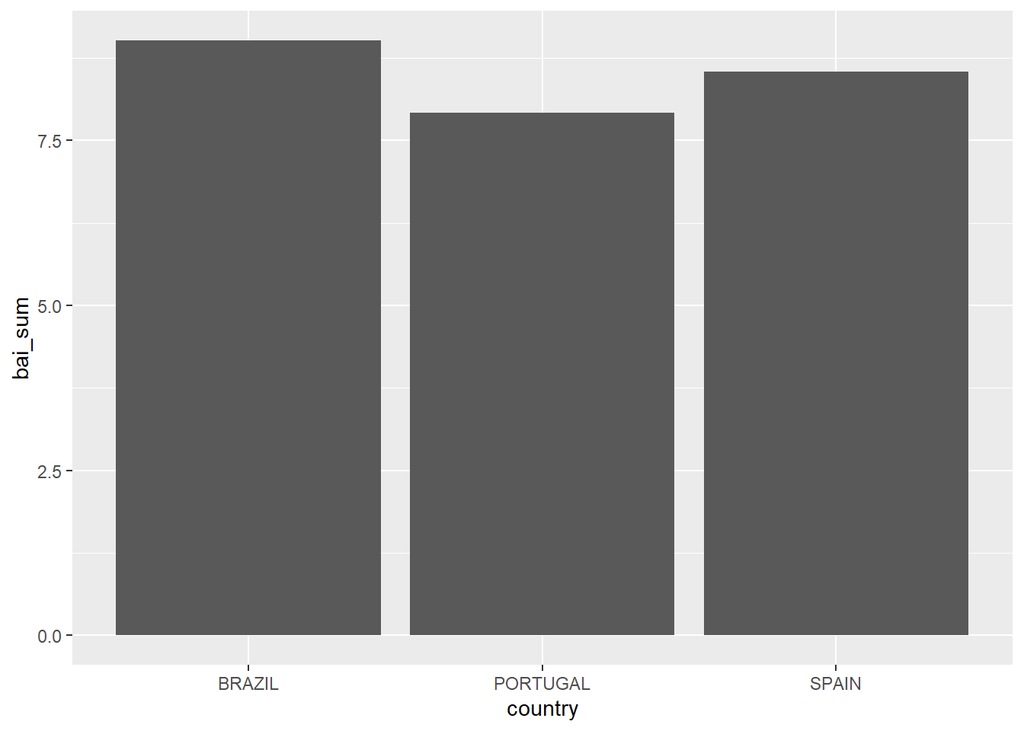

```r
# Gráfico de barras - Gráfico básico

ggplot() +
    # Camada 1 - Barras
    geom_bar(data = dataset,
           mapping = aes(x = country,
                         y = bai_sum),
           stat = "summary",
           fun = mean,
           na.rm = TRUE)
```

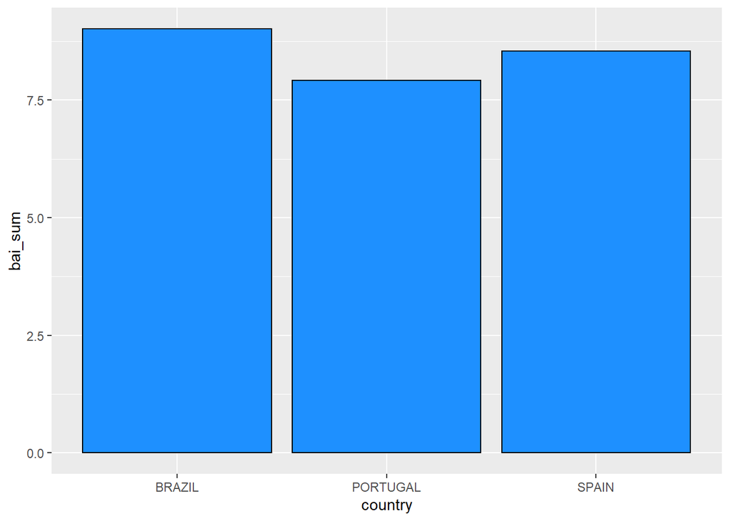

```r
# Gráfico de barras básico, com embelezamento

ggplot() +
    # Camada 1 - Barras com embelezamento
    geom_bar(data = dataset,
           mapping = aes(x = country,
                         y = bai_sum),
           stat = "summary",
           fun = mean,
           na.rm = TRUE,
           fill = "dodgerblue",
           color = "black")
```

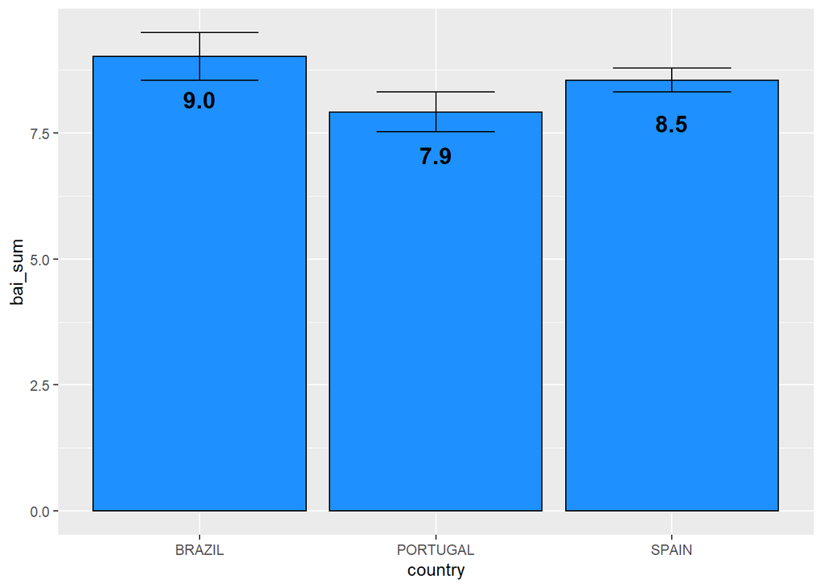

```r
# Gráfico de barras completo: Básico + Outros geoms (barra de erros e texto)

médias_BAI <- # dataframe com as informações que eu vou inserir na camada 2 do gráfico
dataset %>% group_by(country) %>% summarise(mean = mean(bai_sum, na.rm = TRUE))

ggplot() +
  # Camada 1 - Barras com embelezamento
  geom_bar(data = dataset,
           mapping = aes(x = country,
                         y = bai_sum),
           stat = "summary",
           fun = mean,
           na.rm = TRUE,
           fill = "dodgerblue",
           color = "black") +
  # Camada 2 - Barra de Erro
  stat_summary(data = dataset,
               mapping = aes(x=country, y=bai_sum),
               geom = "errorbar",
               fun.data = mean_se,
               width = 0.5) +
  # Camada 3 - Texto (valor das médias dentro das barras)
  geom_text(data = médias_BAI,
            mapping = aes(x = country,
                          y = mean,
                          label = format(mean,digits = 1,nsmall = 1)),
            fontface = "bold", size = 5, vjust = 3)
```

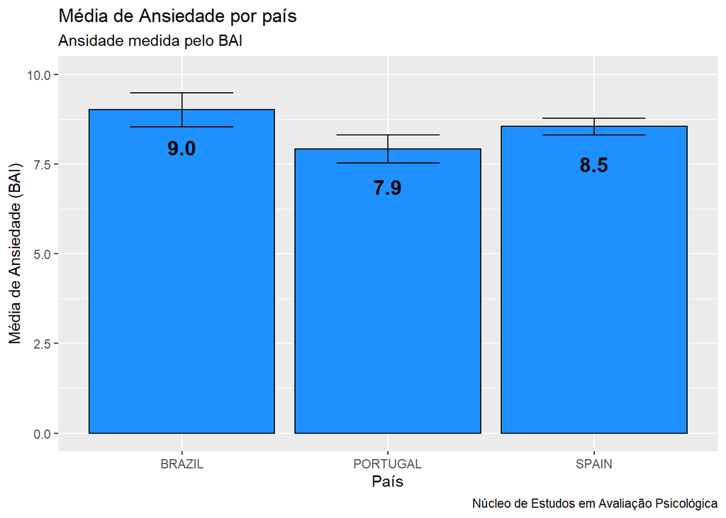

```r
# Gráfico de barras (step3): Básico + Texto + Complementos (lables, themes e coord)

ggplot() +
  # Camada 1 - Barras com embelezamento
  geom_bar(data = dataset,
           mapping = aes(x = country,
                         y = bai_sum),
           stat = "summary",
           fun = mean,
           na.rm = TRUE,
           fill = "dodgerblue",
           color = "black") +
  # Camada 2 - Barra de Erro
  stat_summary(data = dataset, mapping = aes(x=country, y=bai_sum),
               geom = "errorbar",fun.data = mean_se,width = 0.5) +
  # Camada 3 - Texto (valor das médias dentro das barras)
  geom_text(data = médias_BAI,
            mapping = aes(x = country,
                          y = mean,
                          label = format(mean,digits = 1,nsmall = 1)),
            fontface = "bold", size = 5, vjust = 3) +
  # Camada 4 - Labels (título, subtítulo, eixos, caption, theme, coord)
  coord_cartesian(ylim = c(0,10)) +   # mudar escala do eixo y
  # coord_flip() + (se ligar, é necessário ajustar vjust e hjust)
  labs(title = "Média de Ansiedade por país",
       subtitle = "Ansidade medida pelo BAI",
       x = "País",
       y = "Média de Ansiedade (BAI)",
       caption = "Núcleo de Estudos em Avaliação Psicológica") +
  theme_gray()
```

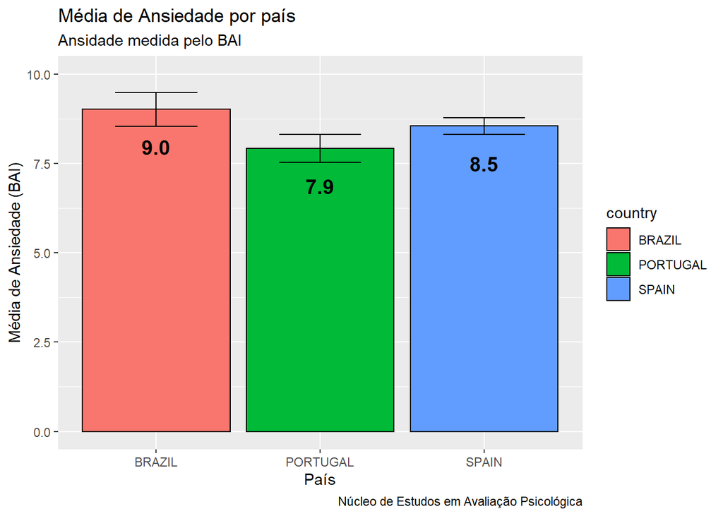

```r
# colorindo por país
# tem que colocar o fill dentro do aes
ggplot() +
  # Camada 1 - Barras com embelezamento
  geom_bar(data = dataset,
           mapping = aes(x = country,
                         y = bai_sum,
           fill = country),
           stat = "summary",
           fun = mean,
           na.rm = TRUE,
           color = "black") +
  # Camada 2 - Barras de erro
  stat_summary(data = dataset,
               mapping = aes(x=country, y=bai_sum),
               geom = "errorbar",
               fun.data = mean_se,width = 0.5,
               na.rm = TRUE) +
  # Camada 3 - Texto (valor das médias dentro das barras)
  geom_text(data = médias_BAI,
            mapping = aes(x = country,
                          y = mean,
                          label = format(mean,digits = 1,nsmall = 1)),
            fontface = "bold", size = 5, vjust = 3) + # mudar vjust e hjust
  # Camada 4 - Labels (título, subtítulo, eixos, caption, theme, coord)
  coord_cartesian(ylim = c(0,10)) +   # mudar escala do eixo y
  # coord_flip() +                      # gráfico horizontal
  labs(title = "Média de Ansiedade por país",
       subtitle = "Ansidade medida pelo BAI",
       x = "País",
       y = "Média de Ansiedade (BAI)",
       caption = "Núcleo de Estudos em Avaliação Psicológica") +
  theme_gray()
```

### Boxplot

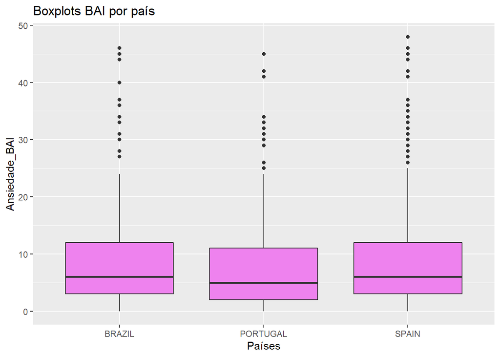

```r
# Gráfico básico
ggplot(data = dataset,
       mapping = aes(x = country, y = bai_sum)) +
  geom_boxplot(fill = "violet") +
  labs(title = "Boxplots BAI por país",
       x = "Países",
       y = "Ansiedade_BAI")
```

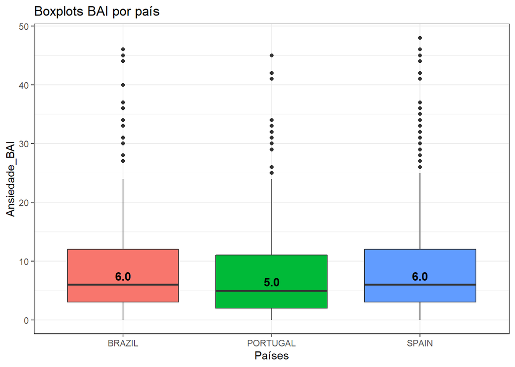

```r
# Gráfico mais completo

## Passo 1 - Criação de um dataframe com informações sobre a mediana
median_boxplot <-
  dataset %>%
  group_by(country) %>%
  summarise(mediana = median(bai_sum, na.rm = TRUE))

## Gráfico
### camada 1
ggplot() +
  geom_boxplot(data = dataset,
               mapping = aes(x = country, y = bai_sum, fill = country),
               show.legend = FALSE,
               na.rm = TRUE) +
### camada 2
  geom_text(data = median_boxplot,
            aes(x = country,
                y = mediana,
                label = format(mediana, digits = 1, nsmall = 1)),
            fontface = "bold", size = 4, vjust = -.5) +
### camada 3
  labs(title = "Boxplots BAI por país",
       x = "Países",
       y = "Ansiedade_BAI") +
### camada 4
  theme_bw()
```

### Gráfico de pontos

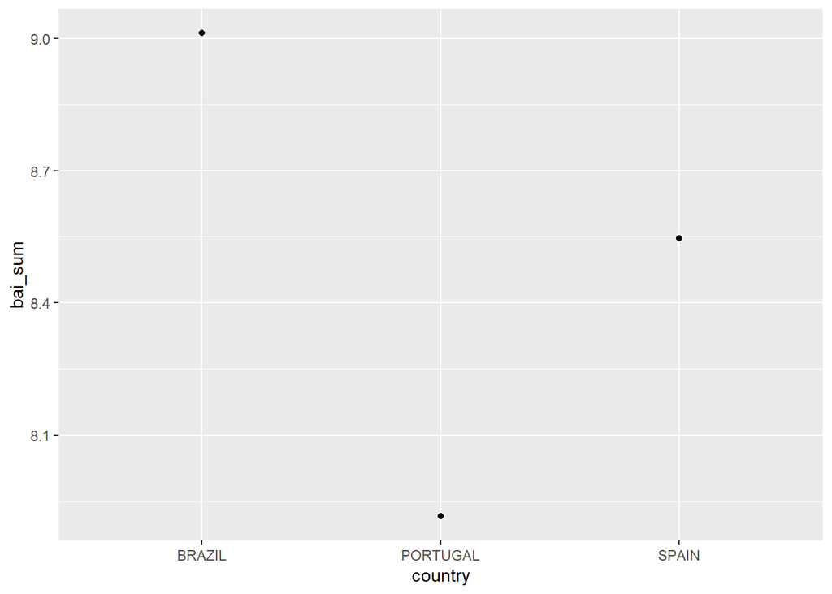

```r
# Gráfico simples
ggplot(dataset, aes(x = country, y = bai_sum)) +
  geom_point(stat = "summary",fun = "mean",na.rm = TRUE)
```

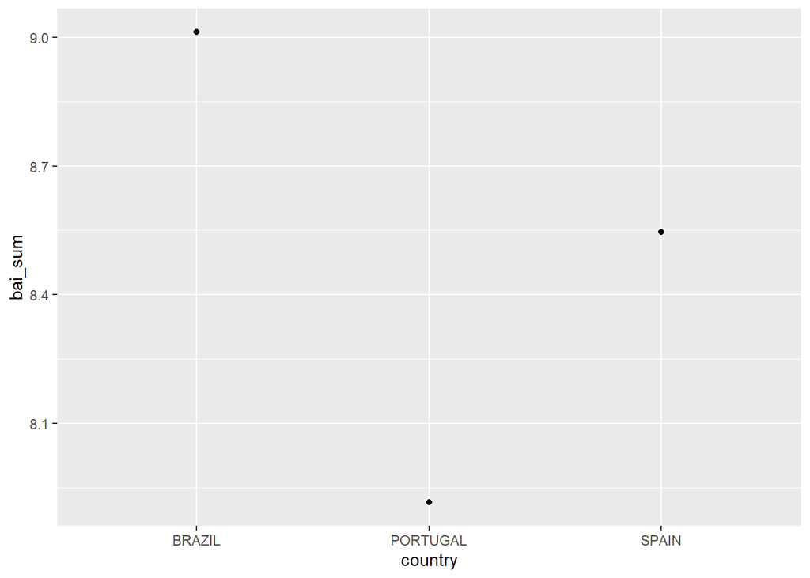

```r
## Outra forma de construir o "gráfico simples"
ggplot(dataset, aes(x = country, y = bai_sum)) +
  stat_summary(geom = "point", fun = "mean")
```

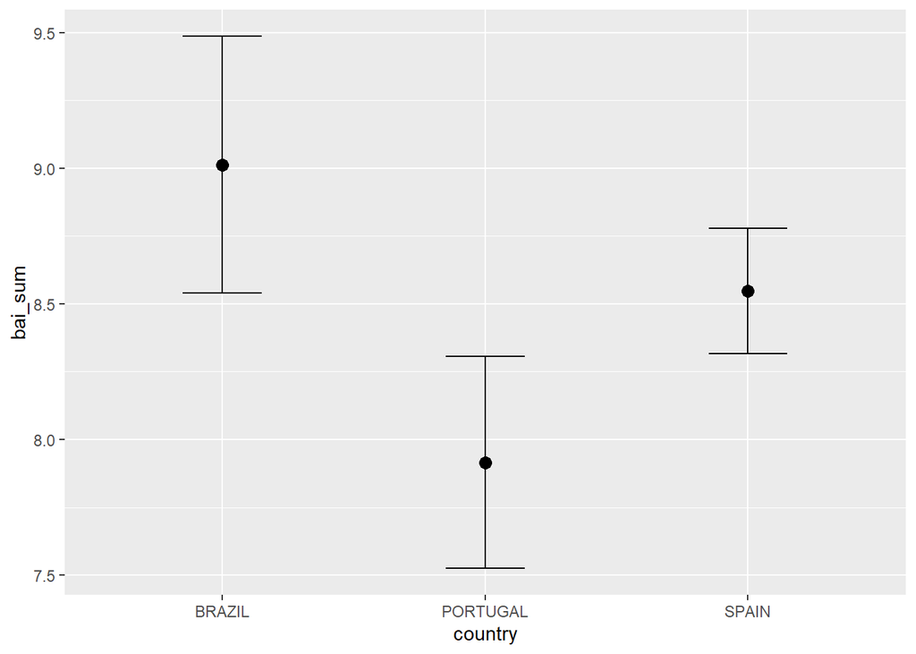

```r
# "Gráfico simples" + Barra de erro

ggplot(dataset,aes(x = country, y = bai_sum)) +
  geom_point(stat = "summary", fun = "mean", size = 3) +
  geom_errorbar(stat = "summary", fun.data = "mean_se", width = 0.3)
```

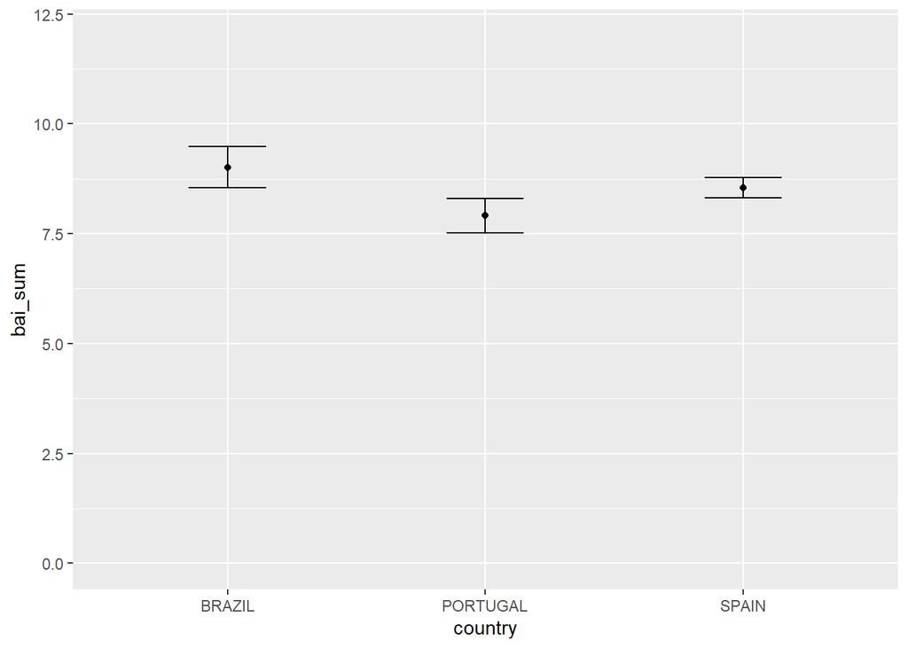

```r
# "Gráfico simples" + Barra de erro + Ajuste das dimensões
ggplot(dataset,aes(x = country, y = bai_sum)) +
  geom_point(stat = "summary", fun = "mean", na.rm = TRUE) +
  geom_errorbar(stat = "summary", fun.data = "mean_se", width = 0.3) +
  coord_cartesian(ylim = c(0,12))
```

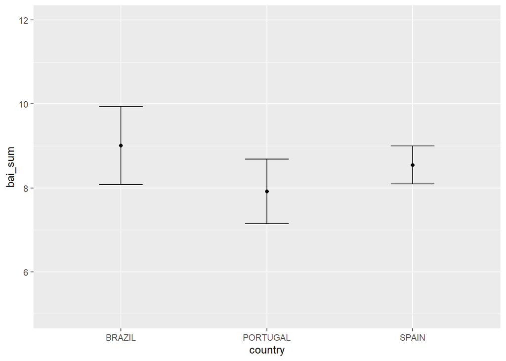

```r
## install.packages("pacman")
pacman::p_load(ggpubr) # ggpubr é um pacote que adiciona algumas funções ao ggplot
                       # com isso fica possível usar a função mean_ci
                       # para calcular intervalo de confiança.

# OBS: a função p_load do pacote pacman verifica se um pacote está instalado e instala se for necessário.

### Barrinha de intervalo de confiança
ggplot(dataset,aes(x = country, y = bai_sum)) +
  geom_point(stat = "summary", fun = "mean", na.rm = TRUE) +
  geom_errorbar(stat = "summary", fun.data = "mean_ci", width = 0.3, na.rm = TRUE) +
  coord_cartesian(ylim = c(5,12))
```

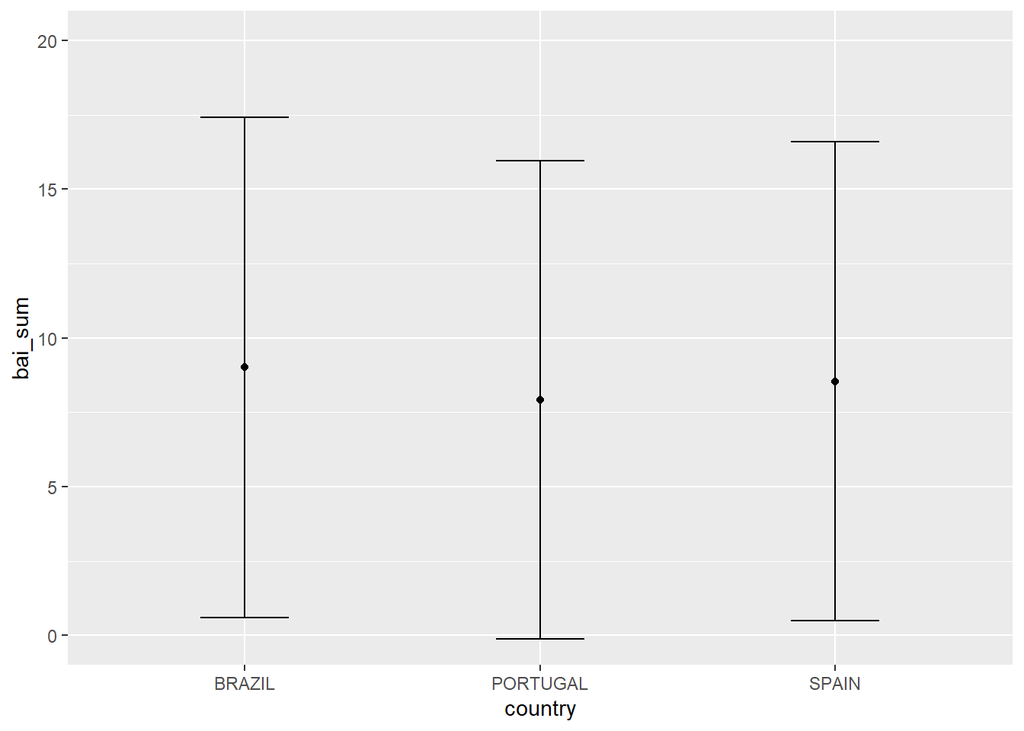

```r
### Barrinha de desvio padrão
ggplot(dataset,aes(x = country, y = bai_sum)) +
  geom_point(stat = "summary", fun = "mean", na.rm = TRUE) +
  geom_errorbar(stat = "summary", fun.data = "mean_sd", width = 0.3, na.rm = TRUE) +
  coord_cartesian(ylim = c(0,20))
```

# Análises de associação entre variáveis

Muitas vezes, o pesquisador está interessado no estudo ou análise de relações entre variáveis. Nesses casos, ele recorrerá a estatísticas como o teste de qui-quadrado (caso tenha variáveis do tipo nominal ou categórica), coeficiente de correlação de Pearson ou regressão linear, entre outras, quando as variáveis forem contínuas.

## Testes de Qui-Quadrado

O teste de qui-quadrado é uma medida de associação entre variáveis categóricas, das quais só temos a frequência de ocorrência. Existem três tipos de testes de qui-quadrado:

- de aderência: quando se deseja verificar as distribuições de probabilidades de cada categoria de uma variável em relação a um valor teórico esperado.
- de homogeneidade: quando se deseja verificar se as distribuições das categorias são as mesmas para diferentes subpopulações de interesse.
- de independência: verficiar se duas variáveis categóricas são independentes

Neste caso, vamos fazer uma análise de qui-quadrado de independência, a mais comumumente utilizada, para verificar se há uma associação entre país e sexo dos participantes do banco de dados dataset. O primeiro passo para isso é montar uma tabela de contingência.

### Tabela de Contingência

Nesse caso, vamos usar a função da base `table()` para gerar uma tabela 2 x 3, duas linhas e três colunas, em que as linhas representarão os sexos masculino e feminino, e as colunas representarão os países: Brasil, Portugal e Espanha.

```r
tabcont_sex_country <- table(dataset$sex,     # linhas
                             dataset$country) # colunas
```

O próximo passo é realizar a análise de qui-quadrado em si.

### Análise de qui-quadrado.

```r
# É bom salvá-la em um objeto porque tem mais informações do que as que são mostradas na análise.

options(scipen = 999) # função para tirar a notação científica de potência.

# Qui-quadrado
chi_sex_country <- chisq.test(tabcont_sex_country)
```

Nesse caso, o X<sup>2</sup> foi de 48,458, para 2 graus de liberdade, e o valor de p foi igual a 3.003e-11 (lê-se 3.003 x 10<sup>-11</sup>). Ou seja, o qui-quadrado foi estatisticamente significativo, indicando que os participantes dos sexos masculino e feminino **não foram** distribuídos homogeneamente dentro dos países.Isso poderia ser relatado da seguinte forma:

*Foi realizada uma análise de qui-quadrado para verificar se havia homogeneidade na distribuição dos sexos masculino e feminino entre os participantes de cada país (Brasil, Portugla e Espanha). Observou-se que a distribuição não foi homogênea (X<sup>2</sup> = 48,458; gl = 2, p-valor = 3,003e-11) e que a falta de homogeneidade se deve aos participantes espanhois, cuja porcentagem de mulheres e mais elevada do que a de homens. Portugal e Brasil apresentaram porcentagens bem parecidas quanto a distribuição por gênero.*

### Representação em tabela

```r
dataset %>%
  tabyl(sex,country,show_na = FALSE) %>%     # função de tabulação do janitor
  adorn_totals(c("row","col")) %>%           # adiciona o N
  adorn_percentages("col") %>%               # adiciona porcentagens (One of "row", "col", or "all".)
  adorn_pct_formatting(
    rounding = "half up",                    # arredondar do cinco pra cima
    digits = 0) %>%                          # número de casas decimais
  adorn_ns() %>%                             # mostra N e % juntas
  pander()                                   # melhora a visualização dos dados.
```

| sex | BRAZIL | PORTUGAL | SPAIN | Total |
| --- | --- | --- | --- | --- |
| F | 53% (166) | 52% (223) | 68% (825) | 62% (1214) |
| M | 47% (149) | 48% (203) | 32% (384) | 38% (736) |
| Total | 100% (315) | 100% (426) | 100% (1209) | 100% (1950) |

Pode-se observar que as distribuições de Brasil e Portugal são muito próximas, mas a da Espanha é bastante diferente, o que deve estar produzindo a significância estatística.

### Representação gráfica

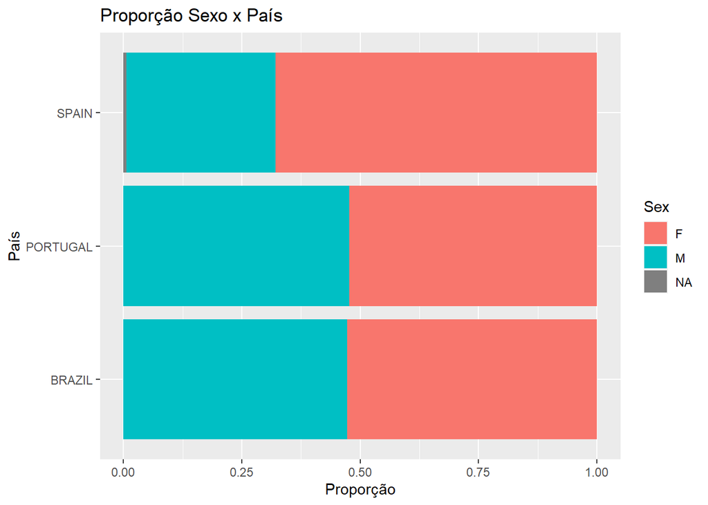

```r
ggplot(dataset, aes(x = country, fill = sex)) +
  geom_bar(position = "fill") +
  coord_flip() +
  labs(title = "Proporção Sexo x País",
       x = "País",
       y = "Proporção",
       fill = "Sex")
```

## Coeficientes de correlação: Pearson, Spearman e Kendall

Quando o interesse do pesquisador é investigar o grau de associação entre variáveis, ele pode empregar o Coeficiente de Correlação de Pearson. Os resultados dessa análise podem variar de -1 a 1. Resultados positivos revelam associação diretamente proporcional entre as variáveis, resultados negativos revelam associação inversamente proporcional entre as variáveis e resultados próximos de zero indicam que não há associação entre as variáveis.

Quando os dados apresentam distribuição normal, usamos o coeficiente de correlação de Pearson. Para dados que não apresentam essa distribuição, usamos a correlação de Kendal ou Spearman. Para isso, vamos usar a função `corrplot()` do pacote `corrplot`. Portanto, é necessário instalar ( `install.packages("corrplot")`) e ativar (`library(corrplot)`) esse pacote.

### Matriz de correlações

```r
# matriz completa (correlações entre todas as variáveis)
matriz_comp <- corr.test(dataset[,c(3,89,92)])

## Visualização dos resultados
matriz_comp
```

```
## Call:corr.test(x = dataset[, c(3, 89, 92)])
## Correlation matrix
##           age bdi_sum bai_sum
## age      1.00   -0.02   -0.04
## bdi_sum -0.02    1.00    0.60
## bai_sum -0.04    0.60    1.00
## Sample Size
##          age bdi_sum bai_sum
## age     1929    1922    1924
## bdi_sum 1922    1949    1948
## bai_sum 1924    1948    1952
## Probability values (Entries above the diagonal are adjusted for multiple tests.)
##          age bdi_sum bai_sum
## age     0.00    0.43    0.11
## bdi_sum 0.43    0.00    0.00
## bai_sum 0.06    0.00    0.00
##
##  To see confidence intervals of the correlations, print with the short=FALSE option
```

```r
## Visualização somente das correlações
matriz_comp$r
```

```
##                 age     bdi_sum     bai_sum
## age      1.00000000 -0.01805132 -0.04334112
## bdi_sum -0.01805132  1.00000000  0.59994091
## bai_sum -0.04334112  0.59994091  1.00000000
```

```r
# matriz parcial (correlações de ansiedade/depressão com idade)
matriz_parc <- corr.test(dataset[,c(89,92)],dataset[,3], method = "pearson")

## Visualização dos resultados
matriz_parc
```

```
## Call:corr.test(x = dataset[, c(89, 92)], y = dataset[, 3], method = "pearson")
## Correlation matrix
##          [,1]
## bdi_sum -0.02
## bai_sum -0.04
## Sample Size
##         [,1]
## bdi_sum 1922
## bai_sum 1924
## These are the unadjusted probability values.
##   The probability values  adjusted for multiple tests are in the p.adj object.
##         [,1]
## bdi_sum 0.43
## bai_sum 0.06
##
##  To see confidence intervals of the correlations, print with the short=FALSE option
```

```r
## Visualização somente das correlações
matriz_parc$r
```

```
##                [,1]
## bdi_sum -0.01805132
## bai_sum -0.04334112
```

Os resultados são apresentados em três matrizes. A primeira com os coeficientes de correlação, a segunda com o número de participantes empregado para o cálculo dos coeficientes, e a terceira com os p-values. Para um coeficiente de correlação ser estatisticamente significativo, o p-value deve ser menor que 0,05, pois isso indica que o valor do coeficiente de correlação obtido seria muito raro em um banco de dados aleatórios.

Na matriz completa, nota-se que as correlações de bdi_sum e bai_sum com idade foram próximas de zero e com p-vlaues de 0,43 e 0,06, respectivamente, indicando que não há associação entre de ansiedade e depressão com idade. Mas a correlação entre bdi_sum e bai_sum foi de 0,60 com p-value igual a 0,00 (nesses casos, relata-se p < 0,01). Exemplo de relato:

*Observou-se que houve correlação positiva e estatisticamente significativa entre ansiedade e depressão (r = 0,60; p < 0,01) e correlações negativas e não significativas de ansiedade (r = -0,04; p = 0,06) e depressão (r = -0.02, p = 0,43) com idade.*